# MyWechatFriends_git

## 微信好友分析

在这个项目中，通过开源的微信个人号接口 [itchat](http://itchat.readthedocs.io/zh/latest/) 来实现 Python 调用微信好友数据，并做一些有趣的统计和分析。

### 项目内容

**0. 向文件传输助手发送信息**

**1. 统计微信好友的男女比例**

**2. 分析微信好友的地域分布**

**3. 生成不同性别好友的微信签名词云图**

**4. 对不同性别好友的签名进行情感分析**

## 0. 登陆并发送打招呼信息

### 登陆

首先导入`itchat`包，并调用`login()`函数登陆网页微信，并扫描二维码以登陆网页微信。

```python
# 导入项目中所需要的包
#coding:utf-8

import pandas as pd
import re
import os
import numpy as np
import pinyin
import matplotlib.pyplot as plt
import seaborn as sb
import itchat

plt.rcParams['font.sans-serif'] = ['SimHei']
%matplotlib inline

print("所有库导入成功！")
```

```
所有库导入成功！
```

```python
# 调用login()函数以登录网页微信
itchat.login()
```

```
Getting uuid of QR code.
Downloading QR code.
Please scan the QR code to log in.
Please press confirm on your phone.
Loading the contact, this may take a little while.
Login successfully as 阳光和鱼
```

```python
#不选择自己的账号信息
dataset = itchat.get_friends(update=True)[1:]
```

### 打个招呼吧

在这个章节中，我们将调用`itchat`的`send()`函数向文件传输助手`filehelper`发送一个打招呼信息吧！

你需要完成以下内容：

- 将想要发送的信息内容赋值给`message`

```python
# 将信息内容赋值给message
message = "我在使用Python发送信息！"
```

```python
# 发送消息
itchat.send(message, 'filehelper')
```

```
<ItchatReturnValue: {'BaseResponse': {'Ret': 0, 'ErrMsg': '请求成功', 'RawMsg': '请求成功'}, 'MsgID': '2787889199822394276', 'LocalID': '15411586078649'}>
```

打开手机微信端的文件传输助手，看看是否收到了这条信息。

```python
### 退出登陆
itchat.logout()
```

```
LOG OUT!
```

```
<ItchatReturnValue: {'BaseResponse': {'ErrMsg': '请求成功', 'Ret': 0, 'RawMsg': 'logout successfully.'}}>
```

### 数据整理

```python
### dataset选择部分列
def preprocess_data(dataset):

    data = [{'NickName':item['NickName'],
 'Sex':item['Sex'],
 'Province':item['Province'],
 'City':item['City'],
 'Signature':item['Signature'],
 'KeyWord':item['KeyWord'],
}
            for item in dataset]

    return data

pre_data = preprocess_data(dataset)
```

```python
df_all = pd.DataFrame()
for i in range(len(pre_data)):
    df = pd.DataFrame([pre_data[i]],index=[pre_data[i]['NickName']])
    df_all =df_all.append(df)
```

```python
df_all.columns
```

```
Index(['City', 'KeyWord', 'NickName', 'Province', 'Sex', 'Signature'], dtype='object')
```

```python
df = df_all[['NickName', 'Sex', 'Province', 'City', 'Signature', 'KeyWord']]
```

## 1. 好友男女比例

根据我们希望探索的问题，需要从数据集中取出以下几个部分：

- NickName：微信昵称
- Sex：性别，1表示男性，2表示女性
- Province：省份
- City：城市
- Signature：微信签名

### 练习：统计男女比例

- 统计好友性别，分为男性、女性与未知三种，赋值到已经定义好的`sex`字典中。

```python
### 输出好友性别数量
sex = df['Sex'].value_counts()
print("我共有好友{0}人，其中男性：{1}人,女性{2}人，未注明性别{3}人。".format(np.sum(sex),sex[1],sex[2],sex[0]))
```

```
我共有好友1296人，其中男性：714人,女性501人，未注明性别81人。
```

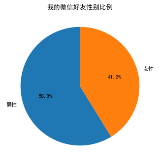

```python
#绘制好友性别圆饼图
plt.figure(figsize=(5,5), dpi=80)
plt.axes(aspect=1)
plt.pie([sex[1], sex[2]],
        labels=['男性','女性'],
        labeldistance = 1.1,
        autopct = '%3.1f%%',
        shadow = False,
        startangle = 90,
        pctdistance = 0.6
)

#plt.legend(loc='upper left',)，此处显示标签
plt.title("我的微信好友性别比例")
plt.show()
```

## 2. 好友地域分布

### 统计好友省份

```python
#去除省份为空值的数据
province = df[df['Province'] != '']['Province'].value_counts()
```

```python
province = province.sort_values(ascending= False)
province.index
province_list = [
    '江苏', '上海', '北京', '河北', '广东', '浙江', '山东', '安徽', '河南', '湖北',
    '福建', '天津', '湖南', '云南', '江西', '广西', '山西', '辽宁', '黑龙江', '陕西',
    '四川',  '吉林','新疆', '西藏', '重庆','海南','甘肃','贵州']
```

```python
#粗略假定国内省份为汉字，港澳台、国外地区为字母。
province_guonei = []
province_guowai= []
for x in province.index:
    if x[0].encode( 'UTF-8' ).isalpha():
        province_guowai.append(x)
    else:
        province_guonei.append(x)
print('好友地域分布：国内:',province[province_guonei].sum(),'人  国外:',province[province_guowai].sum(),'人')
```

```
好友地域分布：国内: 962 人  国外: 70 人
```

```python
province[province_guonei][10:].sum()
```

```
115
```

```python
qita = pd.Series([111,65]).rename({0:'其他省份',1:'国外'})
qita
```

```
其他省份    111
国外       65
dtype: int64
```

```python
province_new = province[province_guonei].head(10).append(qita)
```

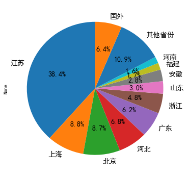

```python
# plot chart
plt.figure(figsize=(6,6))
province_new.plot(kind='pie', autopct='%1.1f%%',startangle=90, shadow=False, legend = False, fontsize=14);
```

## 3. 生成好友个性签名词云图

在这里我们希望生成词云，只需要调用第三方库即可，Python有大量的库可以使用，能极大提高开发效率，是编程入门的绝佳选择。

```python
#得到男女个性签名
df1 =['','','']
df1[1] = df[df['Sex'] ==1]['Signature'].values.tolist()
df1[2] = df[df['Sex'] ==2]['Signature'].values.tolist()
#df1 = pd.DataFrame({'Signature':data1[1]})
```

```python
def signature_wordcloud(data,jpg_n):
    from wordcloud import WordCloud
    import jieba
    tList = []
    for i in range(data.shape[0]):
        signature = data['Signature'][i].replace(" ", "").replace("span", "").replace("class", "").replace("emoji", "")
        rep = re.compile("1f\d.+")
        signature = rep.sub("", signature)
        if len(signature) > 0:
            tList.append(signature)
    text1 = "".join(tList)

    wordlist_jieba = jieba.cut(text1, cut_all=True)
    wl_space_split = " ".join(wordlist_jieba)
    import PIL.Image as Image

    jpg_open = ["man.jpg","woman.jpg"]
    alice_coloring = np.array(Image.open(jpg_open[jpg_n-1]))

    my_wordcloud = WordCloud(background_color="white", max_words=2000, mask=alice_coloring,
                             max_font_size=50, random_state=42, font_path='./SimHei.ttf').generate(wl_space_split)

    #plt.figure(figsize=[12,12])
    plt.imshow(my_wordcloud)
    plt.axis("off")
```

```python
def Signature_sex(data):
    import matplotlib.pyplot as plt
    import numpy.random as rnd

    plt.figure(figsize=[12,12])
    plt.rcParams['font.size'] =12
    #man
    df1 = data[data['Sex'] ==1]['Signature'].values.tolist()
    df1 = pd.DataFrame({'Signature':df1})
    plt.subplot(1,2,1)
    signature_wordcloud(df1,1)
    plt.axis("off")
    plt.text(200,600,'男性')
    #woman
    df2 = data[data['Sex'] ==2]['Signature'].values.tolist()
    df2 = pd.DataFrame({'Signature':df2})
    plt.subplot(1,2,2)
    signature_wordcloud(df2,2)
    plt.axis("off")
    plt.text(200,600,'女性')

    plt.show()
```

[output not shown]

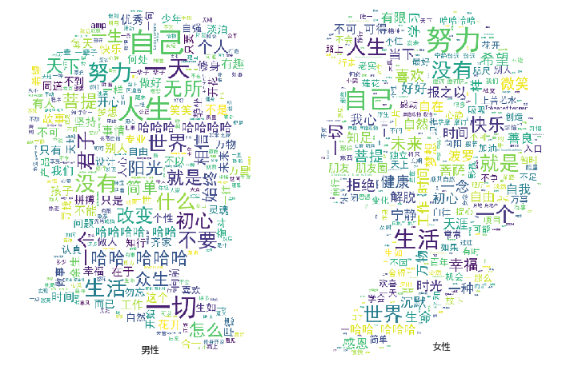

```python
Signature_sex(df)
```

## 4. 对好友签名进行情感分析

在这部分内容中，我们调用了[SnowNLP](https://github.com/isnowfy/snownlp)的情感分析，它是一个python写的类库，可以方便的处理中文文本内容，不用我们实现其中具体的代码。一般来说，情感分析的目的是为了找出作者观点的态度，是正向还是负向，或者更具体的，我们希望知道他的情绪。

我们简单地假设大于0.66表示积极，低于0.33表示消极，其他表示中立。

### 练习：统计好友签名情感分析结果比例

```python
signature_1 = []
for i in df[df['Sex']==1]['Signature']:
    if i != '':
        signature_1.append(i)
```

```python
### 以下内容无需修改，直接运行即可
from snownlp import SnowNLP

sentiments_1 = []
for i in signature_1:
    sentiments_1.append(SnowNLP(i).sentiments)
```

```python
### TODO：统计sentiments中大于0.66的个数
positive_1 = sum(i >0.66 for i in sentiments_1)

### TODO：统计sentiments中大于等于0.33且小于等于0.66的个数
neutral_1 = sum(i >=0.33 for i in sentiments_1)-  sum(i >0.66 for i in sentiments_1)

### TODO：统计sentiments中小于0.33的个数
negative_1 = sum(i <0.33 for i in sentiments_1)
print('男性好友签名情感积极:',positive_1,'中性:',neutral_1,'消极:',negative_1)
```

```
男性好友签名情感积极: 306 中性: 163 消极: 72
```

```python
emotion_1 =[positive_1, neutral_1, negative_1]
emotion_1 = emotion_1 / np.sum(emotion_1)
emotion_1
```

```
array([0.56561922, 0.3012939 , 0.13308688])
```

#### 女性:

```python
signature = []
for i in df[df['Sex']==2]['Signature']:
    if i != '':
        signature.append(i)
```

```python
### 以下内容无需修改，直接运行即可
sentiments = []
for i in signature:
    sentiments.append(SnowNLP(i).sentiments)
```

```python
### TODO：统计sentiments中大于0.66的个数
positive = sum(i >0.66 for i in sentiments)

### TODO：统计sentiments中大于等于0.33且小于等于0.66的个数
neutral = sum(i >=0.33 for i in sentiments)-  sum(i >0.66 for i in sentiments)

### TODO：统计sentiments中小于0.33的个数
negative = sum(i <0.33 for i in sentiments)
print('女性好友签名情感积极:',positive,'中性：',neutral,'消极：',negative)
```

```
女性好友签名情感积极: 214 中性： 112 消极： 54
```

```python
emotion =[positive, neutral, negative]
emotion = emotion / np.sum(emotion)
emotion
```

```
array([0.56315789, 0.29473684, 0.14210526])
```

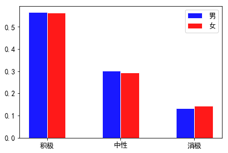

```python
index = np.arange(3)
subjects =['积极','中性','消极']
X = np.arange(3)+1 #X是1,2,3柱的个数
plt.bar(X, emotion_1, alpha=0.9, width = 0.25, facecolor = 'blue', edgecolor = 'white', label='男', lw=1)
plt.bar(X+0.25, emotion, alpha=0.9, width = 0.25, facecolor = 'red', edgecolor = 'white', label='女', lw=1)
plt.legend(loc="upper right"); # label的位置在右上
plt.xticks(index+1.125, subjects);
plt.rcParams['font.size'] = 12
```